# Pro Skills Basketball

Author

Architech Sports and Physical Therapy

[figure not shown]

[figure not shown]

# Abstract

# Contigency Table

Contigency Table

| Pain | Pain N | Pain Y | Hip N | Hip Y | Lat N | Lat Y | Calf N | Calf Y | Quad N | Quad Y | Con. Asymm Low | Con. Asymm High | Ecc. Asymm Low | Ecc. Asymm High | Land. Asymm Low | Land. Asymm High |
| --- | --- | --- | --- | --- | --- | --- | --- | --- | --- | --- | --- | --- | --- | --- | --- | --- |
| N | 57.58 | 0.00 | 45.16 | 9.68 | 27.27 | 30.30 | 15.15 | 42.42 | 25.81 | 29.03 | 45.45 | 12.12 | 36.36 | 21.21 | 15.15 | 42.42 |
| Y | 0.00 | 42.42 | 25.81 | 19.35 | 27.27 | 15.15 | 12.12 | 30.30 | 19.35 | 25.81 | 30.30 | 12.12 | 27.27 | 15.15 | 21.21 | 21.21 |
| **Hip Weakness** |  |  |  |  |  |  |  |  |  |  |  |  |  |  |  |  |
| N | 45.16 | 25.81 | 70.97 | 0.00 | 35.48 | 35.48 | 12.90 | 58.06 | 32.26 | 38.71 | 51.61 | 19.35 | 38.71 | 32.26 | 22.58 | 48.39 |
| Y | 9.68 | 19.35 | 0.00 | 29.03 | 19.35 | 9.68 | 16.13 | 12.90 | 12.90 | 16.13 | 25.81 | 3.23 | 25.81 | 3.23 | 12.90 | 16.13 |
| **Lat Tightness** |  |  |  |  |  |  |  |  |  |  |  |  |  |  |  |  |
| N | 27.27 | 27.27 | 35.48 | 19.35 | 54.55 | 0.00 | 24.24 | 30.30 | 19.35 | 35.48 | 39.39 | 15.15 | 39.39 | 15.15 | 24.24 | 30.30 |
| Y | 30.30 | 15.15 | 35.48 | 9.68 | 0.00 | 45.45 | 3.03 | 42.42 | 25.81 | 19.35 | 36.36 | 9.09 | 24.24 | 21.21 | 12.12 | 33.33 |
| **Calf Tightness** |  |  |  |  |  |  |  |  |  |  |  |  |  |  |  |  |
| N | 15.15 | 12.12 | 12.90 | 16.13 | 24.24 | 3.03 | 27.27 | 0.00 | 6.45 | 22.58 | 27.27 | 0.00 | 24.24 | 3.03 | 9.09 | 18.18 |
| Y | 42.42 | 30.30 | 58.06 | 12.90 | 30.30 | 42.42 | 0.00 | 72.73 | 38.71 | 32.26 | 48.48 | 24.24 | 39.39 | 33.33 | 27.27 | 45.45 |
| **Quad Tightness** |  |  |  |  |  |  |  |  |  |  |  |  |  |  |  |  |
| N | 25.81 | 19.35 | 32.26 | 12.90 | 19.35 | 25.81 | 6.45 | 38.71 | 45.16 | 0.00 | 32.26 | 12.90 | 29.03 | 16.13 | 22.58 | 22.58 |
| Y | 29.03 | 25.81 | 38.71 | 16.13 | 35.48 | 19.35 | 22.58 | 32.26 | 0.00 | 54.84 | 45.16 | 9.68 | 35.48 | 19.35 | 12.90 | 41.94 |
| **Con. Asymmetry** |  |  |  |  |  |  |  |  |  |  |  |  |  |  |  |  |
| N | 45.45 | 30.30 | 51.61 | 25.81 | 39.39 | 36.36 | 27.27 | 48.48 | 32.26 | 45.16 | 75.76 | 0.00 | 51.52 | 24.24 | 30.30 | 45.45 |
| Y | 12.12 | 12.12 | 19.35 | 3.23 | 15.15 | 9.09 | 0.00 | 24.24 | 12.90 | 9.68 | 0.00 | 24.24 | 12.12 | 12.12 | 6.06 | 18.18 |
| **Ecc. Asymmetry** |  |  |  |  |  |  |  |  |  |  |  |  |  |  |  |  |
| N | 36.36 | 27.27 | 38.71 | 25.81 | 39.39 | 24.24 | 24.24 | 39.39 | 29.03 | 35.48 | 51.52 | 12.12 | 63.64 | 0.00 | 30.30 | 33.33 |
| Y | 21.21 | 15.15 | 32.26 | 3.23 | 15.15 | 21.21 | 3.03 | 33.33 | 16.13 | 19.35 | 24.24 | 12.12 | 0.00 | 36.36 | 6.06 | 30.30 |
| **Landing Asymmetry** |  |  |  |  |  |  |  |  |  |  |  |  |  |  |  |  |
| N | 15.15 | 21.21 | 22.58 | 12.90 | 24.24 | 12.12 | 9.09 | 27.27 | 22.58 | 12.90 | 30.30 | 6.06 | 30.30 | 6.06 | 36.36 | 0.00 |
| Y | 42.42 | 21.21 | 48.39 | 16.13 | 30.30 | 33.33 | 18.18 | 45.45 | 22.58 | 41.94 | 45.45 | 18.18 | 33.33 | 30.30 | 0.00 | 63.64 |

p-values from Fisher’s Exact Test. Values <0.05 are significant.

|  | Pain | Hip Weakness | Lat | Calf | Quad | Con. Asymm | Ecc. Asymm | Land. Asymm |
| --- | --- | --- | --- | --- | --- | --- | --- | --- |
| Pain | 0.000 | 0.233 | 0.482 | 1.000 | 1.000 | 0.695 | 1.000 | 0.273 |
| Hip | 0.233 | 0.000 | 0.456 | 0.077 | 1.000 | 0.639 | 0.106 | 0.683 |
| Lat | 0.482 | 0.456 | 0.000 | 0.021 | 0.289 | 0.699 | 0.300 | 0.469 |
| Calf | 1.000 | 0.077 | 0.021 | 0.000 | 0.132 | 0.073 | 0.107 | 1.000 |
| Quad | 1.000 | 1.000 | 0.289 | 0.132 | 0.000 | 0.671 | 1.000 | 0.153 |
| Con. Asymm | 0.695 | 0.639 | 0.699 | 0.073 | 0.671 | 0.000 | 0.420 | 0.678 |
| Ecc. Asymm | 1.000 | 0.106 | 0.300 | 0.107 | 1.000 | 0.420 | 0.000 | 0.133 |
| Land. Asymm | 0.273 | 0.683 | 0.469 | 1.000 | 0.153 | 0.678 | 0.133 | 0.000 |

# Countermovement Jump Results

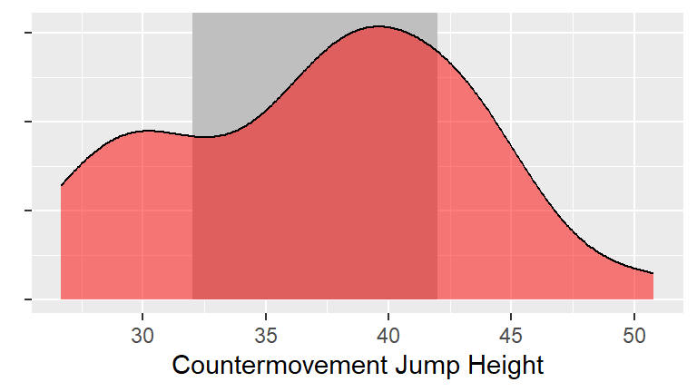

(a) Countermovement Jump Height, in centimeters

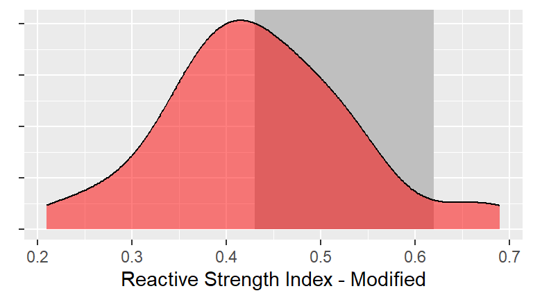

(b) Reactive Strength Index - Modified, in m/s

Figure 1: Distributions of CMJ results

The countermovement jump is an excellent measure of lower body power and explosiveness. Through the use of the Vald ForceDecks, we are able to accurately measure the force an athlete produces over time, which leads to a precise measurement of the athlete’s jump height alongside a range of other useful metrics, such as peak power, the duration of different phases of the jump, and the Reactive Strength Index - Modified (mRSI).  
One of the more useful metrics gathered from the assessment, the mRSI captures a few important characteristics of the jump into one single measurement. Calculated by dividing the Jump Height by the time to takeoff, the mRSI shows how “springy” an athlete is. While two athletes may jump the same height, one might drop down and rebound very quickly, like a powerful spring, while the other takes longer to develop that force, resulting in a lower mRSI. This provides insight into both the athlete’s jump strategy but also fatigue characteristics.  
The above graphs show the distribution of testing scores, alongside normative data from the VALD *Normative Data Report - Basketball 2022*[^1], displayed as a grey region showing the 25th to 75th percentile. Note that the normative values are gathered from collegiate athletes.

# Gator Plank

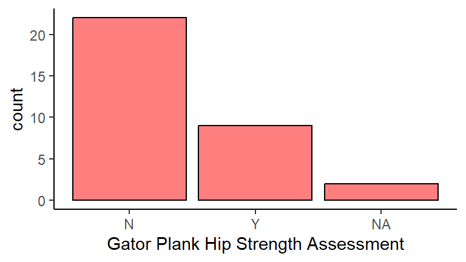

(a) Count of Athletes

Figure 2: Distribution of Gator Plank Results

# FMS Overhead Squat

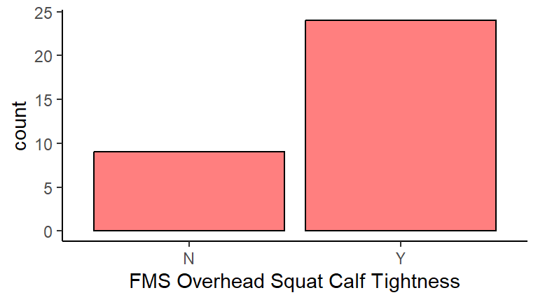

(a) Calf tightness as shown by Overhead Squat

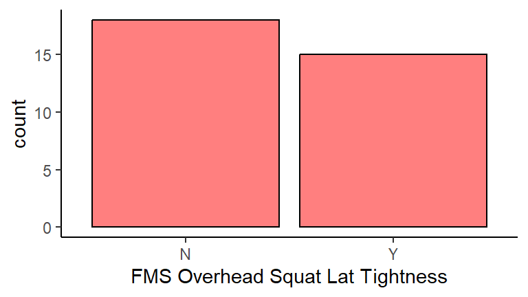

(b) Lat tightness as shown by Overhead Squat

Figure 3: Count of Athletes by FMS Squat Results

The Functional Movement Screen™ is a battery of several assessments that look to determine the quality of an athlete’s movement patterns. While performing the entire FMS™ screen gives a more comprehensive look into an athlete’s movement, the overhead squat, as a single assessment, provides a holistic look into the entire body as an entire system working together. The squat looks at an athlete’s ability to reach good depth while maintaining a relatively upright posture, shoulder flexion in keeping the bar overhead, and weight balanced both between the left and right feet and over the middle of the foot. This allows the practitioner to assess the athlete’s movement capabilities across the whole body at once. During this assessment, we looked at whether tightness in the calves and/or lats were the limiting factor. A ‘Yes’ indicates tightness in that particular area.

# Raw Data

Raw data from testing.

| Athlete | CMJ Jump Height | CMJ mRSI | Eccentric Mean Asymm. | Eccentric Side | Concectric Mean Asymm. | Concectric Side | Landing Mean Asymm. | Landing Side | Pain | Hip Weakness | Tightness Calf | Tightness Lat | Tightness Quad |
| --- | --- | --- | --- | --- | --- | --- | --- | --- | --- | --- | --- | --- | --- |
| Addison Tyree-Rodriguez | 27.94 | 0.36 | 0.17 | Right | 0.08 | Right | 0.17 | Right | N | NA | Y | Y | NA |
| Braven Kincaid | 28.96 | 0.42 | 0.36 | Left | 0.04 | Left | 0.09 | Left | Y | N | Y | Y | N |
| Bryson Demby | 28.96 | 0.26 | 0.08 | Left | 0.12 | Left | 0.07 | Left | Y | Y | Y | Y | N |
| Canyon Hall | 41.40 | 0.55 | 0.01 | Right | 0.00 | Left | 0.06 | Left | Y | Y | N | N | Y |
| Carrington Harris | 38.35 | 0.48 | 0.03 | Right | 0.01 | Right | 0.20 | Left | N | Y | Y | Y | N |
| Connor Walker | 39.12 | 0.53 | 0.15 | Left | 0.03 | Left | 0.13 | Right | Y | N | Y | Y | N |
| Cooper Dillon | 30.23 | 0.37 | 0.07 | Right | 0.00 | Right | 0.23 | Right | N | N | Y | Y | Y |
| Dmitriy Ivanov | 34.04 | 0.42 | 0.24 | Left | 0.10 | Left | 0.25 | Left | Y | N | Y | N | Y |
| Ethan Warren | 38.10 | 0.45 | 0.14 | Right | 0.07 | Right | 0.13 | Right | N | N | N | Y | Y |
| Evan Jones | 44.20 | 0.46 | 0.18 | Right | 0.01 | Right | 0.27 | Right | N | N | Y | Y | Y |
| Grant Warren | 37.59 | 0.44 | 0.03 | Right | 0.11 | Left | 0.09 | Right | N | NA | Y | N | NA |
| Henry Garrison | 45.72 | 0.51 | 0.12 | Right | 0.05 | Right | 0.07 | Left | Y | Y | Y | N | N |
| Ian Ramirez | 33.78 | 0.40 | 0.12 | Right | 0.70 | Left | 0.29 | Right | N | N | Y | Y | N |
| Isaiah Smith III | 26.92 | 0.21 | 0.12 | Right | 0.11 | Right | 0.16 | Right | N | N | Y | N | Y |
| Jacob Pietrafesa | 50.80 | 0.69 | 0.18 | Right | 0.09 | Right | 0.51 | Right | N | N | Y | N | N |
| Jacob Warren | 43.69 | 0.50 | 0.04 | Right | 0.06 | Left | 0.30 | Left | Y | Y | N | N | Y |
| Jaxson Martin | 26.67 | 0.44 | 0.04 | Right | 0.09 | Right | 0.21 | Left | N | N | Y | Y | Y |
| Jayden McCrea | 43.43 | 0.65 | 0.10 | Right | 0.10 | Right | 0.09 | Left | N | N | Y | N | N |
| Jermiah Boswell | 42.93 | 0.56 | 0.09 | Right | 0.04 | Right | 0.09 | Right | Y | N | Y | Y | N |
| Jimmy Neubauer | 38.61 | 0.45 | 0.10 | Right | 0.01 | Left | 0.02 | Right | N | N | Y | N | Y |
| Jovon Nasir Berry | 40.89 | 0.37 | 0.09 | Right | 0.10 | Right | 0.14 | Right | Y | N | Y | N | N |
| KaiRee McCain | 31.24 | 0.31 | 0.07 | Right | 0.12 | Left | 0.18 | Right | N | N | Y | Y | N |
| Ko Ide | 38.10 | 0.41 | 0.04 | Right | 0.02 | Right | 0.29 | Right | N | N | N | N | Y |
| Latterio Robinson | 29.97 | 0.48 | 0.11 | Right | 0.06 | Left | 0.19 | Left | N | N | Y | Y | Y |
| Logan Massenberg | 38.10 | 0.40 | 0.18 | Left | 0.18 | Left | 0.32 | Left | Y | N | Y | N | Y |
| Maxim Stassenko | 42.42 | 0.30 | 0.05 | Right | 0.03 | Right | 0.06 | Left | Y | N | N | N | Y |
| Maxwell Ober | 36.58 | 0.37 | 0.04 | Left | 0.09 | Right | 0.06 | Right | N | N | Y | Y | N |
| Nikhil Nanduri | 34.80 | 0.42 | 0.09 | Right | 0.07 | Left | 0.22 | Right | N | Y | N | N | Y |
| Nolan Keady | 30.99 | 0.37 | 0.00 | Right | 0.06 | Right | 0.05 | Left | Y | N | Y | N | Y |
| Reid Stanley | 42.67 | 0.53 | 0.03 | Right | 0.05 | Left | 0.23 | Left | Y | Y | Y | Y | Y |
| Saul Lieberman | 42.42 | 0.50 | 0.01 | Left | 0.03 | Left | 0.11 | Left | Y | Y | N | N | Y |
| Tommy Claire | 37.59 | 0.35 | 0.02 | Left | 0.02 | Left | 0.05 | Left | N | Y | N | N | N |
| Trevor James | 39.62 | 0.38 | 0.10 | Right | 0.08 | Right | 0.18 | Right | N | N | N | N | N |

## Footnotes

[^1]: Normative data from: https://hub.valdperformance.com/app/reports/dataReports